# Lab02

Yifei Liu

19/03/2021

## Task 1: Examine the data

1.1 - There are multiple observations in a row, and multiple variables in a column. This makes the data untidy.

1.2 - There are numerous merged cells that overlap individual cells.

We may also want the unit of measure to be stored separately in a column of its own instead of tacked on after the description.

Random whitespace between blocks of data (may or may not be be an issue, for now I’m just assuming it could cause problems later in data preprocessing)

1.3 - I would spend some time researching the common methods used by Data Engineers to combat the data issues described above such as missing data, merged cells, overlapping variables etc and mimic their approach.

## Task 2:

```r
# load libraries
library(tidyverse)
library(readr)
library(zoo)
library(purrr)
library(knitr)
library(readxl)
library(ggplot2)
# not shown : knitr::opts_chunk$set(echo = TRUE)

raw.df <- read_excel("simulation_outpu1_raw.xlsx", skip = 7, col_names = FALSE)

df <- raw.df

# creating header names
header_names <- c('small_concrete',
                  'small_curtain',
                  'medium_concrete',
                  'medium_curtain',
                  'large_concrete',
                  'large_curtain')
?expand.grid

names(df) <- c('weather',
               'description',
               header_names)

# create 'group' variable, i.e. sensible cooling/heating
x1 <- as.data.frame(matrix(rep(NA, length(df)), nrow=1))
names(x1)<-names(df)
#xq
df2 <- bind_rows(x1,df)
df2 <- df2 %>%
  mutate(group = ifelse(is.na(description), 'overall',
                   ifelse(description=='Sensible Cooling', 'sensible_cooling',
                     ifelse(description=='Sensible Heating', 'sensible_heating', NA))))

# fill group=NA values with previous non-na
group.vt <- zoo(df2$group) # turn group variable into zoo object
df2$group <- na.locf(group.vt) # last obs carry forward

# delete non-informative rows
num_na_per_row.vt <- apply(df2, 1, function(x){
  sum(is.na(x))
})

df2 <- df2[which(num_na_per_row.vt<7),]

# locf on 'weather'
weather.vt <- zoo(df2$weather) # turn group variable into zoo object
df2$weather <- na.locf(weather.vt) # last obs carry forward

tidydf2 <- coredata(df2) %>% gather(class, value, 3:8) %>%
  separate(class, c('office_size', 'office_type'))

kable(head(tidydf2, n=6))
```

| weather | description | group | office_size | office_type | value |
| --- | --- | --- | --- | --- | --- |
| Very Hot Humid (Honolulu, HI) | Heating energy [GJ] | overall | small | concrete | 0.000 |
| Very Hot Humid (Honolulu, HI) | Cooling energy [GJ] | overall | small | concrete | 47.070 |
| Very Hot Humid (Honolulu, HI) | Total Cosumption [GJ] | overall | small | concrete | 162.470 |
| Very Hot Humid (Honolulu, HI) | Calculated Design Air Flow [m3/s] | sensible_cooling | small | concrete | 0.256 |
| Very Hot Humid (Honolulu, HI) | User Design Air Flow [m3/s] | sensible_cooling | small | concrete | 0.308 |
| Very Hot Humid (Honolulu, HI) | Thermostat Setpoint Temperature at Peak Load [C] | sensible_cooling | small | concrete | 23.890 |

2.1 - The data has now been turned into a tidy format, see above table for a preview of tidied data.

## Task 3:

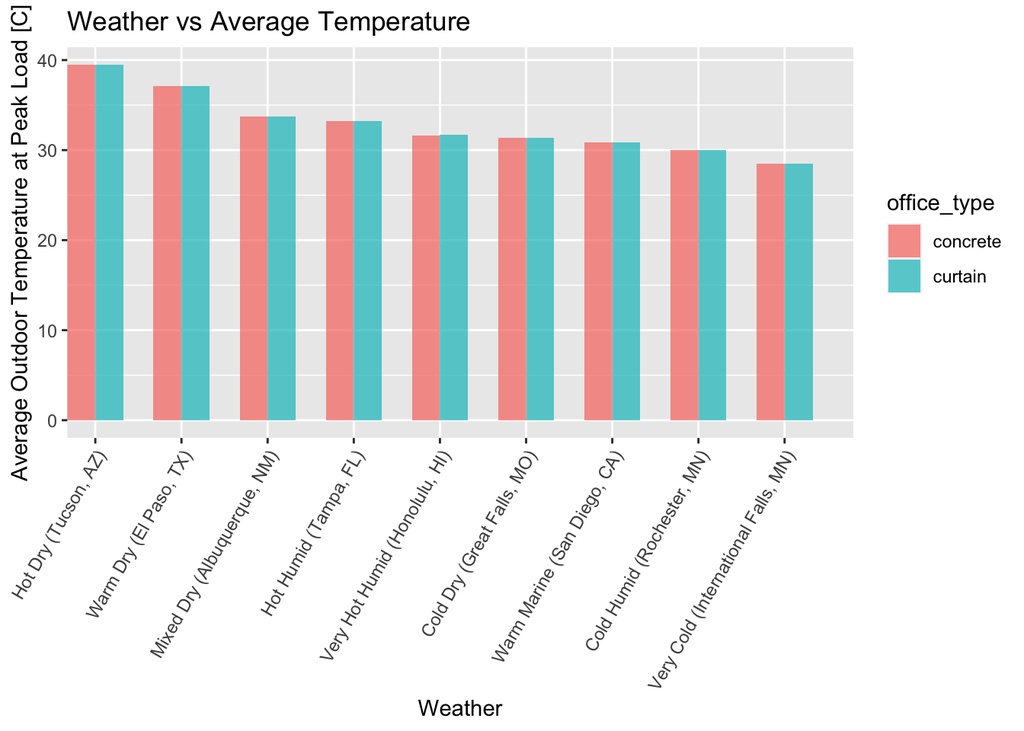

```r
task3 <- coredata(tidydf2) %>%
  filter(description=='Outdoor Temperature at Peak Load [C]') %>%
  filter(group=='sensible_cooling') %>%
  filter(office_size=='small')

task3df1 <- fortify.zoo(task3) %>%
  group_by(coredata(weather),office_type) %>%
  summarise(avgtemp = mean(value), .groups = 'keep') %>%
  arrange(desc(avgtemp))

task3df1 <- fortify.zoo(task3df1)

names(task3df1)[2] <- 'weather'

task3df1 %>%
  ggplot(aes(x = weather, y = avgtemp, fill = office_type)) +
  geom_bar(position = 'dodge', stat='identity', width = 1.3, alpha=0.7) +
  scale_x_discrete(limits = task3df1$weather) +
  theme(axis.text.x = element_text(angle=60,hjust=1)) +
  ggtitle('Weather vs Average Temperature') +
  ylab('Average Outdoor Temperature at Peak Load [C]') +
  xlab('Weather')
```

3.1 - We can see from the plot above that the weather does indeed affect temperature at peak load.

We can also observe that the office type does NOT affect the peak load temperature, as both curtain and concrete have the same peak load temperature.

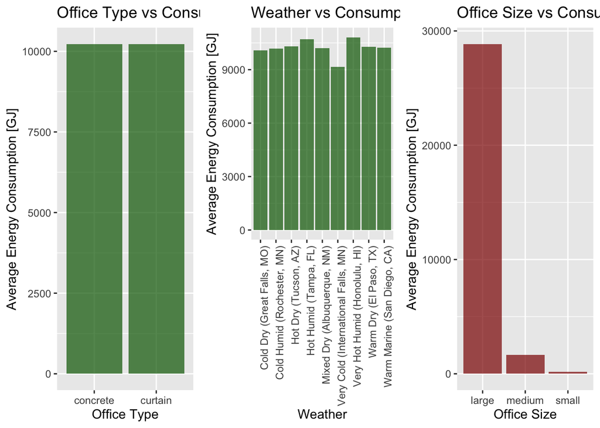

```r
task3p2 <- coredata(tidydf2) %>%
  filter(description=='Total Cosumption [GJ]') %>%
  select('weather', 'office_type', 'office_size', 'value')

grouptype <- group_by(task3p2, office_type) %>%
  summarise(mean = mean(value)) %>%
  arrange(desc(mean)) %>%
  ggplot(aes(x= coredata(office_type), y = mean))+
  geom_bar(fill = 'darkgreen', alpha=0.7,stat = 'identity') +
  scale_x_discrete(guide=guide_axis(n.dodge=1))+
  ggtitle('Office Type vs Consumption') +
  ylab('Average Energy Consumption [GJ]') +
  xlab('Office Type')

groupsize <- group_by(task3p2, office_size) %>%
  summarise(mean = mean(value)) %>%
  arrange(desc(mean)) %>%
  ggplot(aes(x= coredata(office_size), y = mean))+
  geom_bar(fill = 'darkred', alpha=0.7,stat = 'identity') +
  scale_x_discrete(guide=guide_axis(n.dodge=1))+
  ggtitle('Office Size vs Consumption') +
  ylab('Average Energy Consumption [GJ]') +
  xlab('Office Size')

groupweather <- group_by(task3p2, weather) %>%
  summarise(mean = mean(value)) %>%
  arrange(desc(mean)) %>%
  ggplot(aes(x= coredata(weather), y = mean))+
  geom_bar(fill = 'darkgreen', alpha=0.7,stat = 'identity') +
  scale_x_discrete(guide=guide_axis(n.dodge=1,)) +
  theme(axis.text.x = element_text(angle=90,hjust=1)) +
  ggtitle('Weather vs Consumption') +
  ylab('Average Energy Consumption [GJ]') +
  xlab('Weather')


library(cowplot)
plot_grid(grouptype, groupweather, groupsize,  ncol = 3)
```

3.2 - As we can observe from the trio of graphs above, office type has little to no effect on energy consumption, however weather and office size does have an effect on energy consumption.

Between the two factors that affect energy consumption, it is clear that office size has the most significant impact on energy consumption, as the average energy consumption between small, medium, and large offices are substantial.